# Vowel Sounds Classification: Final Project for STAT 8090

## 6. Clustering

### 6. (20 points) To simplify it, select observations from classes 1, 3, 6 and 10 and conduct clustering analysis on these observations. Try the hierarchical clustering methods, K-means method and model-based clustering method. Comment on the performance of these methods.

In clustering analysis, since 4 classes of data are introduced, 4 is selected as the target number of clusters for the sake of comparison. Also, 4 is determined to be optimum number of clusters based on with in sum of squares analysis and elbow method.

Model performances also can be interpreted in several perspectives. First, in terms of computation and time efficiency, k-means and hierarchical clustering have faster processing, while model based clustering is the most costly methodology. Also, model based clustering is computationally the most costly methodology. Other than that, models can be interpreted on the basis of assumptions. K-means and hierarchical clustering are unsupervised methods and do not assume any information regarding the dataset. While, model based clustering has distinct assumption of multivariate normality of the data. This is an important limitation for model based clustering and due to this reason, analysis is conducted in a careful manner. In terms of explainability of models to non-technical individuals, hierarchical and k-means are more easily explainable while due to limitations, model based clustering is more challenging to interpret.’

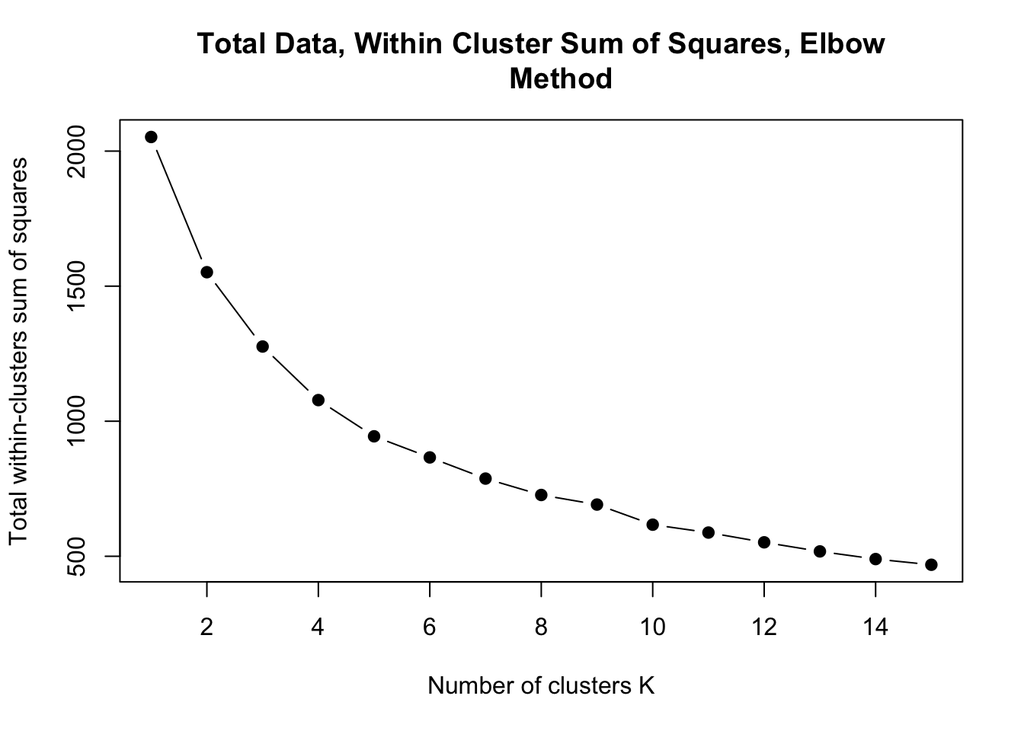

```r
#k-means
train.clustering <- filter(train.df, y == 1 |
                             y == 3 | y == 6 |
                             y == 10)

train.cl.df <- subset(train.clustering, select = -c(y))
train.y.df <- subset(train.clustering, select = c(y))

test.clustering <- filter(test.df, y == 1 |
                            y == 3 | y == 6 |
                            y == 10)

test.cl.df <- subset(test.clustering, select = -c(y))
test.y.df <- subset(test.clustering, select = c(y))

#since training and testing is not relevant in clustering,
#two datasets are merged to have a larger set of data.

df.cluster <- rbind(train.cl.df, test.cl.df)
df.y.cluster <- rbind(train.y.df, test.y.df)

# function to compute total within-cluster sum of square
wss <- function(k) {
  kmeans(df.cluster, k, nstart = 10)$tot.withinss
}

# Compute and plot wss for k = 1 to k = 15
k.values <- 1:15

# extract wss for 2-15 clusters
wss_values <- map_dbl(k.values, wss)

plot(k.values, wss_values,
     type="b", pch = 19,
     xlab="Number of clusters K",
     ylab="Total within-clusters sum of squares",
     main = "Total Data, Within Cluster Sum of Squares, Elbow
     Method")
```

```r
#based on the elbow analysis, 4 clusters are decided to be optimum.

model.k.means <- kmeans(df.cluster,
                        4, iter.max = 20,
                        nstart = 1)

print(model.k.means)
```

```
## K-means clustering with 4 clusters of sizes 70, 130, 90, 70
##
## Cluster means:
##         x.1       x.2         x.3       x.4         x.5       x.6         x.7
## 1 -2.015571 0.3066857 -1.35117143 0.6338714 -0.02074286 1.3218714  0.13804286
## 2 -2.847115 1.7643692 -0.55787692 0.5254538 -0.37493846 0.4938154 -0.01137692
## 3 -3.750278 0.3905667  0.07835556 1.4956778  0.41944444 0.8179889 -0.26795556
## 4 -4.643671 2.9394000 -0.03211429 0.6003143 -0.06990000 0.3861857 -0.08962857
##          x.8        x.9       x.10
## 1  0.7600143 -0.6409429 -0.4620571
## 2  0.1381846 -0.2079923  0.1207154
## 3 -0.3110444 -0.5814222  0.2524000
## 4  0.2549143 -0.2013571 -0.3038571
##
## Clustering vector:
##   [1] 3 1 2 2 3 1 2 2 3 1 2 2 3 1 2 2 3 1 2 2 3 1 2 2 3 1 2 4 3 1 2 4 3 1 2 4 3
##  [38] 1 2 4 3 1 2 4 3 1 2 4 1 1 2 2 1 1 2 4 1 1 2 4 1 1 2 4 1 1 2 4 1 1 2 4 1 1
##  [75] 2 2 1 1 2 2 1 1 2 2 1 1 2 2 1 1 2 2 1 1 2 4 3 3 2 4 3 3 2 4 3 3 2 4 3 3 2
## [112] 4 3 3 2 4 3 3 2 4 3 3 2 4 3 3 2 4 3 3 2 4 3 3 2 4 3 3 2 4 3 3 2 4 3 2 2 4
## [149] 3 2 2 4 3 2 2 4 3 2 2 4 3 3 2 4 3 3 2 4 4 3 2 4 4 3 2 4 4 3 2 4 4 3 2 4 4
## [186] 3 2 4 4 3 2 4 1 1 2 3 1 1 2 3 1 3 2 3 1 1 2 3 3 1 2 3 3 1 2 3 1 1 2 4 1 1
## [223] 2 4 1 1 2 4 1 1 2 4 1 1 2 4 1 1 2 4 3 2 2 4 3 2 2 4 3 2 2 4 3 2 2 4 3 2 2
## [260] 4 1 2 2 4 1 1 2 3 1 1 2 3 1 1 2 3 1 1 2 3 1 1 2 3 1 1 2 3 3 2 2 4 3 2 2 4
## [297] 3 2 2 4 3 2 2 4 3 2 2 4 3 2 2 4 3 2 2 4 3 2 2 4 3 2 2 3 3 2 2 3 3 2 2 4 3
## [334] 2 2 4 3 2 2 4 3 2 2 4 3 2 2 4 3 2 2 4 3 2 2 4 3 2 2 4
##
## Within cluster sum of squares by cluster:
## [1] 162.9202 347.1513 312.8407 261.1919
##  (between_SS / total_SS =  47.2 %)
##
## Available components:
##
## [1] "cluster"      "centers"      "totss"        "withinss"     "tot.withinss"
## [6] "betweenss"    "size"         "iter"         "ifault"
```

```r
k.means.vector <- model.k.means$cluster

#Hierarchical Clustering
dist.cluster <- dist(df.cluster, "euclidean")
model.hiearch <- hclust(dist.cluster, "average")

print(model.hiearch)
```

```
##
## Call:
## hclust(d = dist.cluster, method = "average")
##
## Cluster method   : average
## Distance         : euclidean
## Number of objects: 360
```

```r
model.hiearch$call
```

```
## hclust(d = dist.cluster, method = "average")
```

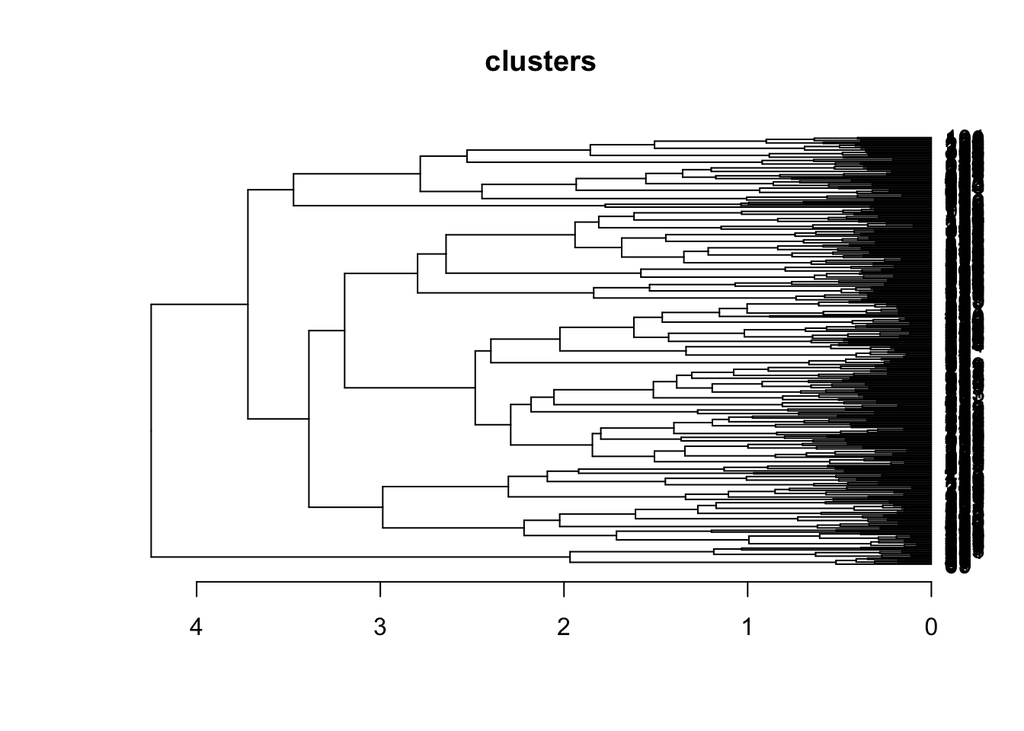

```r
#model.hiearch$merge
#model.hiearch$height
#model.hiearch$merge

model.4.hierarch <- cutree(model.hiearch, k = 4)

labels.hierach.4 <- model.4.hierarch

plot(as.dendrogram(model.hiearch),
    horiz=TRUE,
    main="clusters")
```

```r
'Below, hiearchical clustering for variables is presented.'
```

```
## [1] "Below, hiearchical clustering for variables is presented."
```

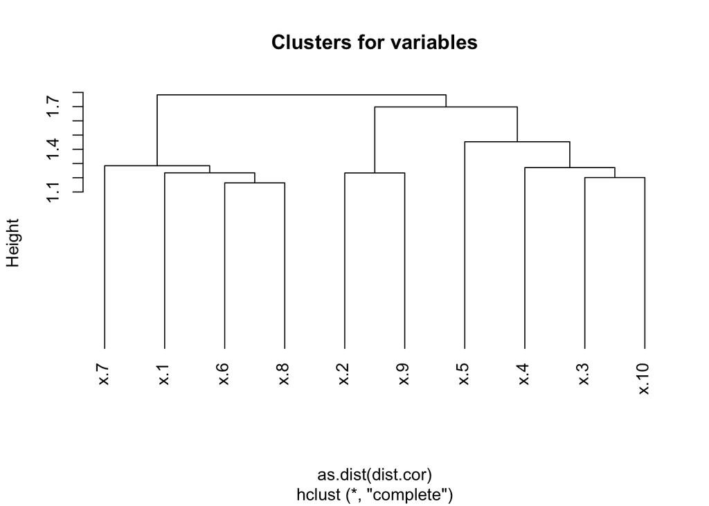

```r
cormtx <- cor(df.cluster)
dist.cor <- sqrt(2*(1-cormtx))
hc.c <- hclust(as.dist(dist.cor),
               "complete")
plot(hc.c, hang=-1, main="Clusters for variables")
```

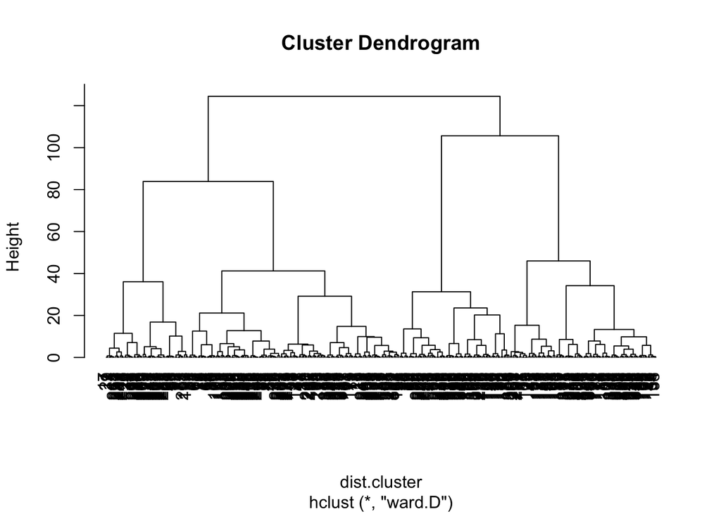

```r
#Ward

hc.eu.w <- hclust(dist.cluster, "ward")
#hc.eu.w$merge
#hc.eu.w$height
plot(hc.eu.w,hang = -1)
```

```r
#Model-Clustering

'To conduct model clustering, we need to make sure the dataset
behaves normal. To test and assure normality, a small qqnorm survey
is conducted.'
```

```
## [1] "To conduct model clustering, we need to make sure the dataset\nbehaves normal. To test and assure normality, a small qqnorm survey\nis conducted."
```

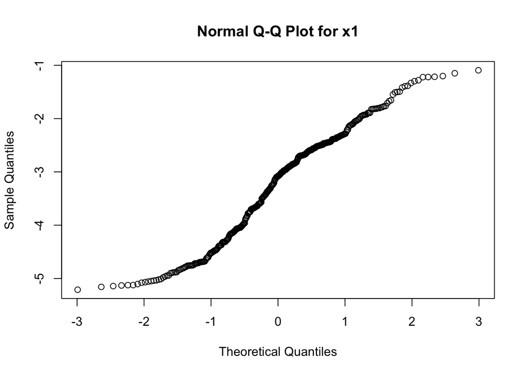

```r
qq.x1 <- qqnorm(df.cluster$x.1, main = "Normal Q-Q Plot for x1")
```

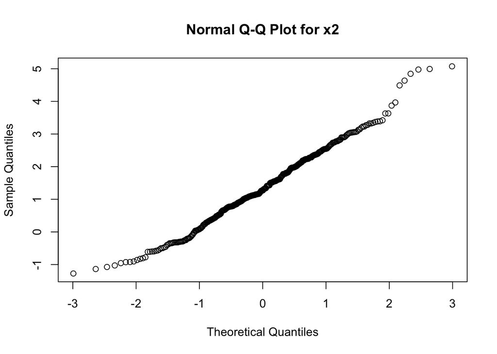

```r
qq.x2 <- qqnorm(df.cluster$x.2, main = "Normal Q-Q Plot for x2")
```

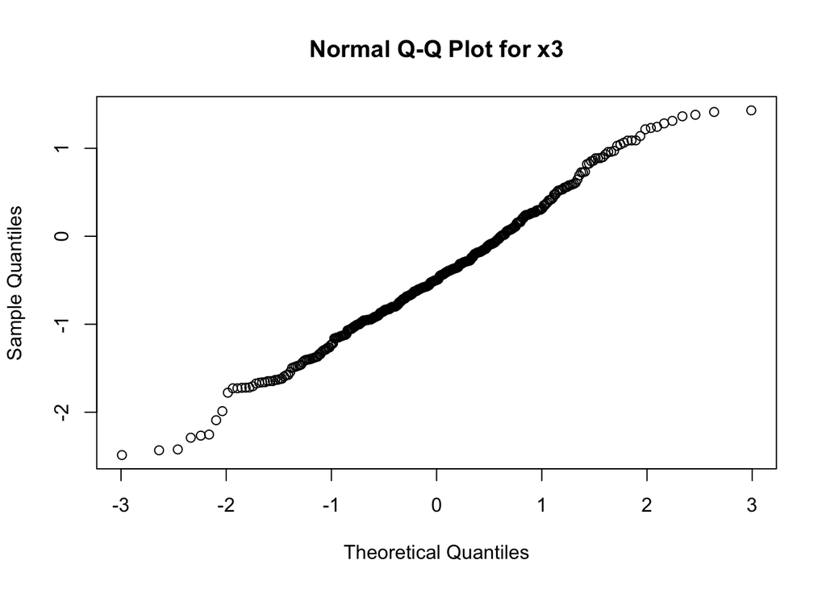

```r
qq.x3 <- qqnorm(df.cluster$x.3, main = "Normal Q-Q Plot for x3")
```

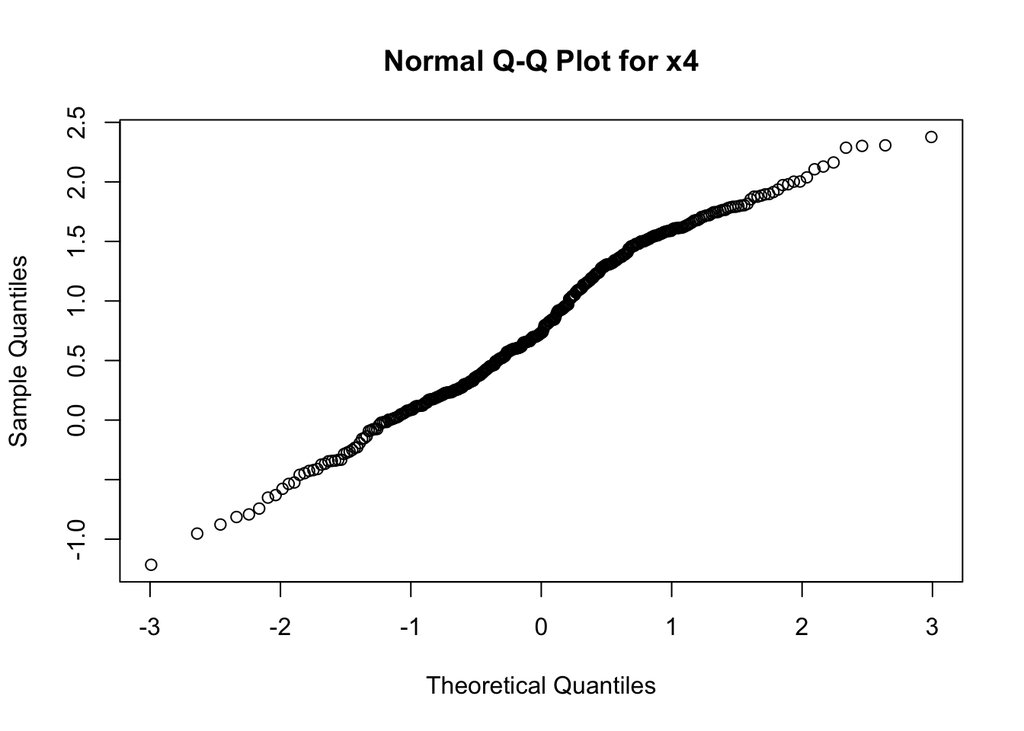

```r
qq.x4 <- qqnorm(df.cluster$x.4, main = "Normal Q-Q Plot for x4")
```

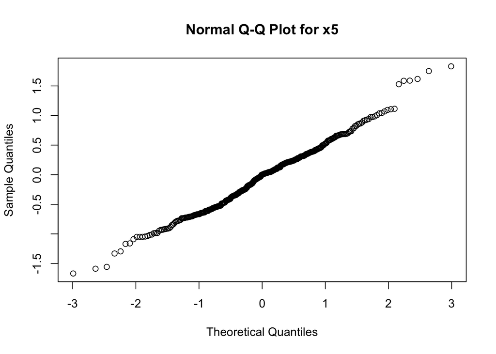

```r
qq.x5 <- qqnorm(df.cluster$x.5, main = "Normal Q-Q Plot for x5")
```

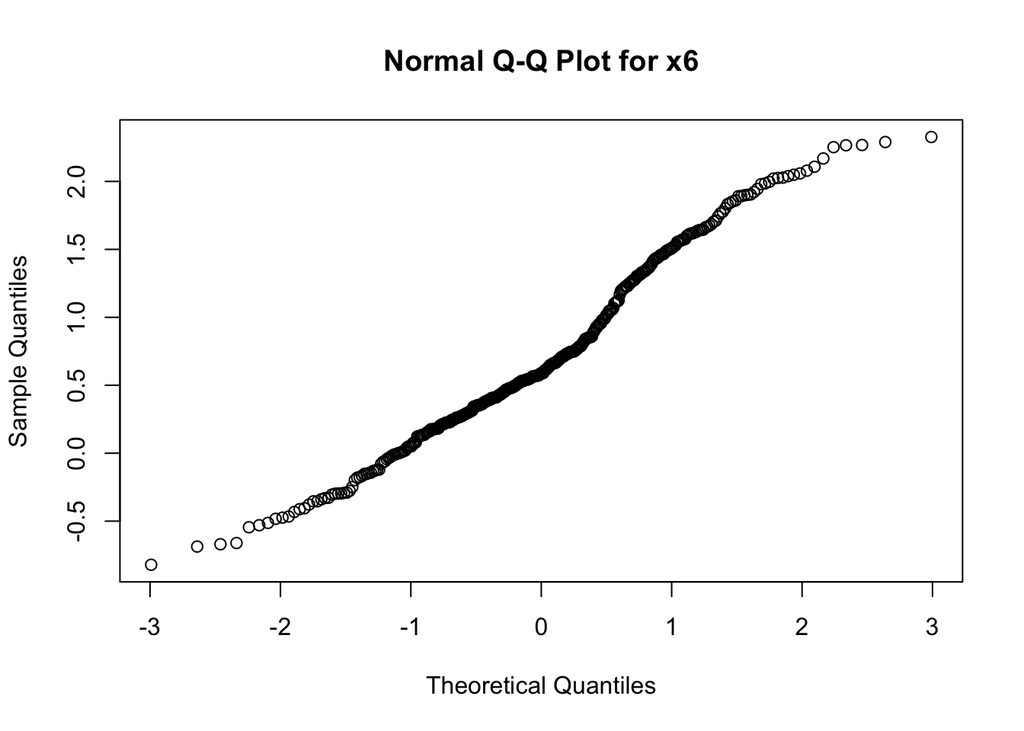

```r
qq.x6 <- qqnorm(df.cluster$x.6, main = "Normal Q-Q Plot for x6")
```

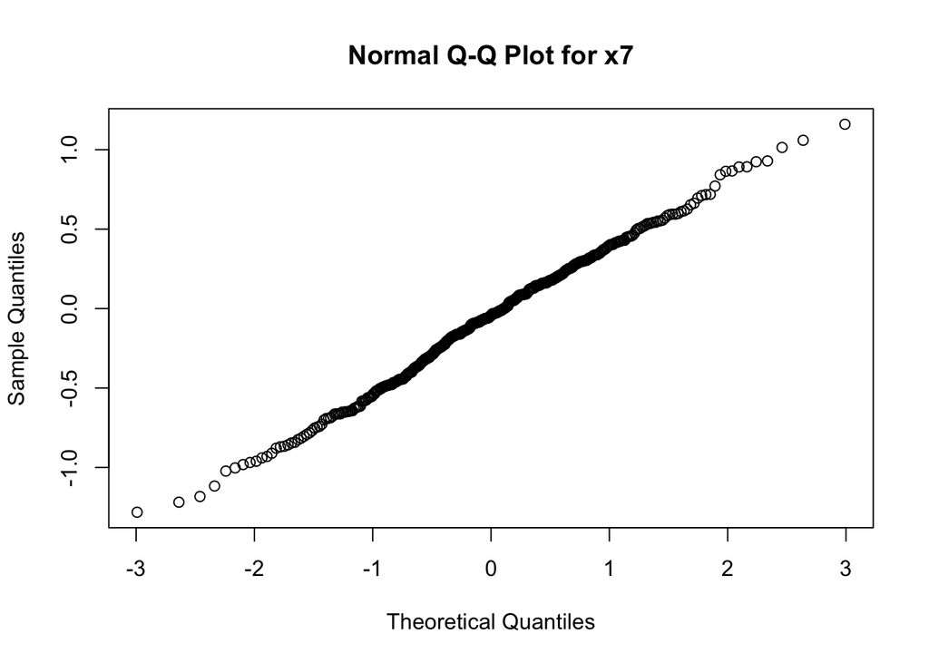

```r
qq.x7 <- qqnorm(df.cluster$x.7, main = "Normal Q-Q Plot for x7")
```

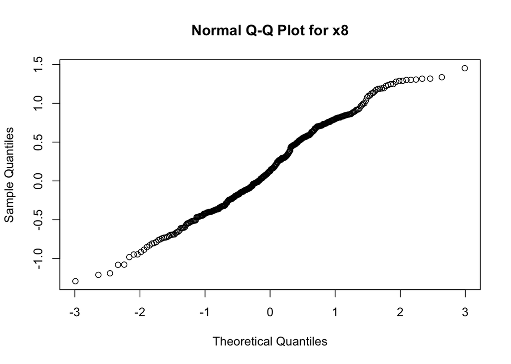

```r
qq.x8 <- qqnorm(df.cluster$x.8, main = "Normal Q-Q Plot for x8")
```

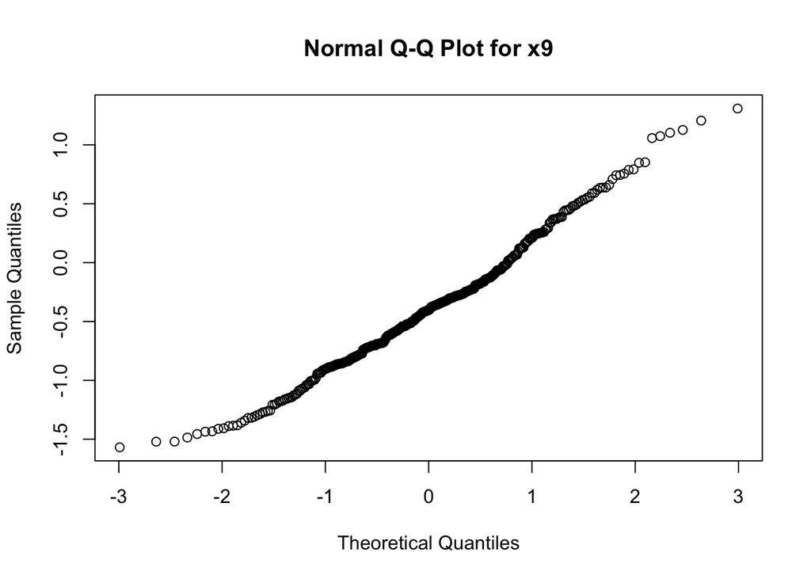

```r
qq.x9 <- qqnorm(df.cluster$x.9, main = "Normal Q-Q Plot for x9")
```

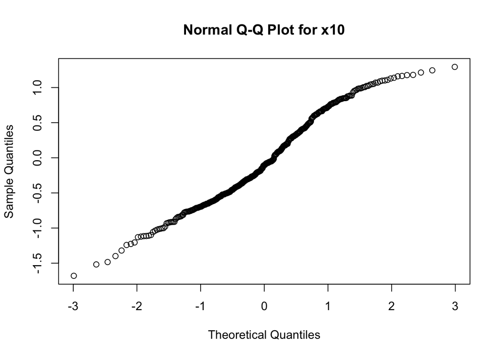

```r
qq.x10 <- qqnorm(df.cluster$x.10, main = "Normal Q-Q Plot for x10")
```

```r
'Although tails can be determined to be slightly problematic,
qqnorm plots show a normal behaviour from almost all variables.'
```

```
## [1] "Although tails can be determined to be slightly problematic,\nqqnorm plots show a normal behaviour from almost all variables."
```

```r
model.mdl.cluster <- Mclust(df.cluster, G = 4)
model.mdl.cluster.BIC <- mclustBIC(df.cluster)
print(model.mdl.cluster)
```

```
## 'Mclust' model object: (VEV,4)
##
## Available components:
##  [1] "call"           "data"           "modelName"      "n"
##  [5] "d"              "G"              "BIC"            "loglik"
##  [9] "df"             "bic"            "icl"            "hypvol"
## [13] "parameters"     "z"              "classification" "uncertainty"
```

```r
#plot(model.mdl.cluster, what = "density")
#plot(model.mdl.cluster, what = "uncertainty")

sort(model.mdl.cluster$uncertainty,
     decreasing = TRUE) %>% head()
```

```
## [1] 0.4743065 0.4293299 0.4041706 0.2878831 0.1721705 0.1431361
```

```r
summary(model.mdl.cluster)
```

```
## ----------------------------------------------------
## Gaussian finite mixture model fitted by EM algorithm
## ----------------------------------------------------
##
## Mclust VEV (ellipsoidal, equal shape) model with 4 components:
##
##  log-likelihood   n  df       BIC       ICL
##       -2033.847 360 236 -5456.815 -5462.971
##
## Clustering table:
##   1   2   3   4
##  78 101 117  64
```

```r
summary(model.mdl.cluster.BIC)
```

```
## Best BIC values:
##              VEV,8       VEV,9     VVV,9
## BIC      -4910.135 -4953.56028 -5110.196
## BIC diff     0.000   -43.42542  -200.061
```

```r
model.mdl.cluster$parameters[2]
```

```
## $mean
##             [,1]        [,2]        [,3]        [,4]
## x.1  -2.59186562 -3.90349765 -3.64228876 -2.35692733
## x.2   0.44301682  2.63445810  0.92746411  1.27907316
## x.3  -1.26428923 -0.42168633  0.07265177 -0.46078281
## x.4   1.20524594  0.27881141  1.37229722  0.10698648
## x.5  -0.17396573 -0.36012651  0.32833753 -0.08714459
## x.6   1.55329253  0.53097448  0.38591619  0.58484058
## x.7   0.03719617  0.18692663 -0.39607010  0.03392484
## x.8   0.75967089  0.25581326 -0.41188508  0.37457195
## x.9  -0.61698678 -0.26111779 -0.52567570 -0.03681151
## x.10 -0.47516190 -0.08889929  0.52078198 -0.46902376
```

```r
model.mdl.cluster$parameters[3]
```

```
## $variance
## $variance$modelName
## [1] "VEV"
##
## $variance$d
## [1] 10
##
## $variance$G
## [1] 4
##
## $variance$sigma
## , , 1
##
##              x.1         x.2          x.3          x.4          x.5
## x.1   0.65580465 -0.15748359 -0.249265163 -0.237886924 -0.122598733
## x.2  -0.15748359  0.47373934  0.062999753  0.045554446 -0.107744642
## x.3  -0.24926516  0.06299975  0.268361930  0.143077084  0.003856539
## x.4  -0.23788692  0.04555445  0.143077084  0.221474572  0.044508216
## x.5  -0.12259873 -0.10774464  0.003856539  0.044508216  0.119917127
## x.6  -0.08105209 -0.07254249 -0.068716800  0.031267968  0.071709219
## x.7   0.08211830 -0.18311420 -0.013344969  0.005295349  0.041782769
## x.8   0.20144421 -0.01969308 -0.081146490 -0.062972347 -0.034022655
## x.9  -0.04129262  0.07176578  0.053248423  0.007710820 -0.004933526
## x.10  0.12022351  0.08798341  0.006186699 -0.064401124 -0.062982989
##                x.6           x.7         x.8          x.9         x.10
## x.1  -0.0810520855  0.0821182978  0.20144421 -0.041292620  0.120223508
## x.2  -0.0725424924 -0.1831142024 -0.01969308  0.071765776  0.087983413
## x.3  -0.0687167997 -0.0133449691 -0.08114649  0.053248423  0.006186699
## x.4   0.0312679680  0.0052953489 -0.06297235  0.007710820 -0.064401124
## x.5   0.0717092191  0.0417827689 -0.03402265 -0.004933526 -0.062982989
## x.6   0.2529228217  0.0009711262 -0.02693780 -0.105425158 -0.068825384
## x.7   0.0009711262  0.1306106917  0.01932898  0.021016032 -0.029705414
## x.8  -0.0269377960  0.0193289799  0.12313066  0.017549544  0.050413400
## x.9  -0.1054251585  0.0210160318  0.01754954  0.194629013  0.007801554
## x.10 -0.0688253836 -0.0297054141  0.05041340  0.007801554  0.109727912
##
## , , 2
##
##               x.1         x.2         x.3          x.4          x.5
## x.1   1.121013628 -0.52733993 -0.30590039 -0.076346539 -0.247930646
```

[output cut: 164 more lines]

```
## x.7   0.12329866 -0.10927048 -0.01821097  0.07916395 -0.09407647 -0.3166111
## x.8   0.06252446  0.23868509 -0.02832713 -0.55066428 -0.37653077  0.2938255
## x.9  -0.51553302  0.08048931 -0.28747191  0.26253613 -0.12852631  0.2780690
## x.10 -0.08560453  0.20154339 -0.13226050  0.14648763 -0.09259528 -0.5369543
##              x.7         x.8        x.9         x.10
## x.1  -0.17361249  0.37908682 -0.1692678  0.439208485
## x.2  -0.01412955  0.03128086 -0.2284059  0.270277990
## x.3  -0.46793517 -0.17750911 -0.1087062  0.265107251
## x.4   0.24426735  0.45454412 -0.4111354  0.001588936
## x.5   0.06860562 -0.33994862 -0.2841829 -0.056028634
## x.6   0.13016454  0.05706485 -0.3402105 -0.086665939
## x.7  -0.67217472  0.23298858 -0.3985900 -0.438394051
## x.8  -0.21692340 -0.57214004 -0.1094765 -0.143501223
## x.9   0.32158279  0.02728508 -0.1898195 -0.584935107
## x.10  0.25901650 -0.34058921 -0.5787367  0.313337069
```

```r
model.mdl.cluster$parameters[4]
```

```r
model.mdl.labels <- model.mdl.cluster$classification
model.mdl.labels
```

```
##   [1] 1 1 2 1 1 1 2 1 1 1 2 1 1 1 2 1 1 1 2 1 1 1 2 1 3 4 4 2 3 4 4 2 3 4 4 2 3
##  [38] 4 4 2 3 4 4 2 3 4 4 2 1 1 1 2 1 1 1 2 1 1 1 2 1 1 1 2 1 1 1 2 1 1 1 2 1 4
##  [75] 4 2 1 4 4 2 1 4 4 2 1 4 4 2 1 4 4 2 1 4 4 2 3 3 2 2 3 3 2 2 3 3 2 2 3 3 2
## [112] 2 3 3 3 2 3 3 3 2 3 3 4 2 3 3 4 2 3 3 4 2 3 3 4 2 3 3 4 2 3 3 4 2 3 3 2 2
## [149] 3 3 2 2 3 3 2 2 3 3 2 2 3 3 2 2 3 3 3 2 3 3 2 2 3 3 2 2 3 3 2 2 3 3 2 2 3
## [186] 3 2 2 3 3 2 2 1 4 4 3 1 4 4 3 1 4 4 3 1 4 4 3 1 4 2 3 1 4 2 3 1 1 2 2 1 1
## [223] 2 2 1 1 2 2 1 1 2 2 1 1 2 2 1 1 2 2 1 4 4 2 1 4 4 2 1 4 4 2 1 4 4 2 1 4 4
## [260] 2 1 4 4 2 1 4 4 1 1 4 4 1 1 4 4 1 1 4 4 1 1 4 4 1 1 4 4 1 3 3 2 2 3 3 2 2
## [297] 3 3 2 2 3 3 2 2 3 3 2 2 3 3 2 2 3 3 3 3 3 3 3 3 3 3 3 3 3 3 3 3 3 3 3 3 3
## [334] 3 3 3 3 3 2 3 3 3 2 3 3 3 2 3 3 3 2 3 3 3 2 3 3 3 2 3
```

```r
#Comparing Clustering models

#Clustering Assignments based on different models can be shown as:

k.means.vector
```

```
##   [1] 3 1 2 2 3 1 2 2 3 1 2 2 3 1 2 2 3 1 2 2 3 1 2 2 3 1 2 4 3 1 2 4 3 1 2 4 3
##  [38] 1 2 4 3 1 2 4 3 1 2 4 1 1 2 2 1 1 2 4 1 1 2 4 1 1 2 4 1 1 2 4 1 1 2 4 1 1
##  [75] 2 2 1 1 2 2 1 1 2 2 1 1 2 2 1 1 2 2 1 1 2 4 3 3 2 4 3 3 2 4 3 3 2 4 3 3 2
## [112] 4 3 3 2 4 3 3 2 4 3 3 2 4 3 3 2 4 3 3 2 4 3 3 2 4 3 3 2 4 3 3 2 4 3 2 2 4
## [149] 3 2 2 4 3 2 2 4 3 2 2 4 3 3 2 4 3 3 2 4 4 3 2 4 4 3 2 4 4 3 2 4 4 3 2 4 4
## [186] 3 2 4 4 3 2 4 1 1 2 3 1 1 2 3 1 3 2 3 1 1 2 3 3 1 2 3 3 1 2 3 1 1 2 4 1 1
## [223] 2 4 1 1 2 4 1 1 2 4 1 1 2 4 1 1 2 4 3 2 2 4 3 2 2 4 3 2 2 4 3 2 2 4 3 2 2
## [260] 4 1 2 2 4 1 1 2 3 1 1 2 3 1 1 2 3 1 1 2 3 1 1 2 3 1 1 2 3 3 2 2 4 3 2 2 4
## [297] 3 2 2 4 3 2 2 4 3 2 2 4 3 2 2 4 3 2 2 4 3 2 2 4 3 2 2 3 3 2 2 3 3 2 2 4 3
## [334] 2 2 4 3 2 2 4 3 2 2 4 3 2 2 4 3 2 2 4 3 2 2 4 3 2 2 4
```

```r
labels.hierach.4
```

```
##   [1] 1 1 1 1 1 1 1 1 1 1 1 1 1 1 1 1 1 1 1 1 1 1 1 1 1 1 1 2 1 1 1 2 1 1 1 2 1
##  [38] 1 1 2 1 1 1 2 1 1 1 2 3 1 1 2 3 1 1 2 3 1 1 2 3 1 1 2 3 1 1 2 3 1 1 2 3 1
##  [75] 1 2 3 1 1 2 3 1 1 2 3 1 1 2 3 1 1 2 3 1 1 2 1 1 1 2 1 1 1 2 1 1 1 2 1 1 1
## [112] 2 1 1 1 2 1 1 1 2 1 1 1 2 1 1 1 2 1 1 1 2 1 1 1 2 1 1 1 2 1 1 1 2 1 1 1 2
## [149] 1 1 1 2 1 1 1 2 1 1 1 2 1 1 1 2 1 1 1 2 1 1 1 4 1 1 1 4 1 1 1 4 1 1 1 4 1
## [186] 1 1 4 1 1 1 4 3 1 1 1 3 1 1 1 3 1 1 1 1 1 1 1 1 1 1 1 1 1 1 1 1 1 1 2 1 1
## [223] 1 2 1 1 1 2 1 1 1 2 1 1 1 2 1 1 1 2 1 1 1 2 1 1 1 2 1 1 1 2 1 1 1 2 1 1 1
## [260] 2 1 1 1 2 1 1 1 1 1 1 1 1 1 1 1 1 1 1 1 1 1 1 1 1 1 1 1 1 1 1 1 2 1 1 1 2
## [297] 1 1 1 2 1 1 1 2 1 1 1 2 1 1 1 2 1 1 1 1 1 1 1 1 1 1 1 1 1 1 1 1 1 1 1 1 1
## [334] 1 1 1 1 1 1 1 1 1 1 1 1 1 1 1 1 1 1 1 1 1 1 1 1 1 1 1
```

```r
model.mdl.labels
```

```
##   [1] 1 1 2 1 1 1 2 1 1 1 2 1 1 1 2 1 1 1 2 1 1 1 2 1 3 4 4 2 3 4 4 2 3 4 4 2 3
##  [38] 4 4 2 3 4 4 2 3 4 4 2 1 1 1 2 1 1 1 2 1 1 1 2 1 1 1 2 1 1 1 2 1 1 1 2 1 4
##  [75] 4 2 1 4 4 2 1 4 4 2 1 4 4 2 1 4 4 2 1 4 4 2 3 3 2 2 3 3 2 2 3 3 2 2 3 3 2
## [112] 2 3 3 3 2 3 3 3 2 3 3 4 2 3 3 4 2 3 3 4 2 3 3 4 2 3 3 4 2 3 3 4 2 3 3 2 2
## [149] 3 3 2 2 3 3 2 2 3 3 2 2 3 3 2 2 3 3 3 2 3 3 2 2 3 3 2 2 3 3 2 2 3 3 2 2 3
## [186] 3 2 2 3 3 2 2 1 4 4 3 1 4 4 3 1 4 4 3 1 4 4 3 1 4 2 3 1 4 2 3 1 1 2 2 1 1
## [223] 2 2 1 1 2 2 1 1 2 2 1 1 2 2 1 1 2 2 1 4 4 2 1 4 4 2 1 4 4 2 1 4 4 2 1 4 4
## [260] 2 1 4 4 2 1 4 4 1 1 4 4 1 1 4 4 1 1 4 4 1 1 4 4 1 1 4 4 1 3 3 2 2 3 3 2 2
## [297] 3 3 2 2 3 3 2 2 3 3 2 2 3 3 2 2 3 3 3 3 3 3 3 3 3 3 3 3 3 3 3 3 3 3 3 3 3
## [334] 3 3 3 3 3 2 3 3 3 2 3 3 3 2 3 3 3 2 3 3 3 2 3 3 3 2 3
```

```r
kmeans.ARI <- adjustedRandIndex(df.y.cluster$y, k.means.vector)
hierarc.ARI <- adjustedRandIndex(df.y.cluster$y,
                                 labels.hierach.4)
mdl.ARI <- adjustedRandIndex(df.y.cluster$y, model.mdl.labels)

kmeans.ARI
```

```
## [1] 0.4228796
```

```r
hierarc.ARI
```

```
## [1] 0.1265136
```

```r
mdl.ARI
```

```
## [1] 0.2186533
```

```r
clustring_matrix_all <- matrix(c(kmeans.ARI,
                                     hierarc.ARI,
                                     mdl.ARI),
                         nrow = 3, ncol = 1, byrow = T)

colnames(clustring_matrix_all) <- c("Adjusted Rand Index")
rownames(clustring_matrix_all) <- c("K-Means Clustering",
                                        "Hierarchical         Clustering", "Model Based Clustering")

clustring_matrix_all
```

```
##                                 Adjusted Rand Index
## K-Means Clustering                        0.4228796
## Hierarchical         Clustering           0.1265136
## Model Based Clustering                    0.2186533
```

## 7. [10 points) What is the final conclusion based on the previous methods?

#### As the result, LDA has been the most successful model where classes 5,7,10 are removed. Removal of classes generated a positive impact in the results. PCA based analyses did not provide useful outcomes. Some reasons on this might be due to nature of the dataset. In the original data where all classes are present, QDA has been more successful than LDA. While, PCA application when classes are removed does not provide useful results, just like the initial PCA model. It can be concluded that the most succesful application has been done with LDA where certain classes are removed.

#### Training errors are significantly lower, when compared to testing. This shows a sign of overfitting in all models. LDA and QDA can be mentioned to have tendency for overfit in the scope of this analysis.

#### Clustering also provided significant insights. K-means has been the most successful result, where 0.42 is achieved as the adjusted rand index. In terms of performance, k-means showed it can be the most trusted model. Model based clustering and hierarchical clustering did not provide adjusted rand index as high as k-means.

#### As the future work, advanced models can be implemented and tested to reach better misclassification rates.